# Programación Orientada a Procedimientos (POP)

La programación tradicional, que hace uso de lenguajes de alto nivel como COBOL, FORTRAN y C, se identifica ampliamente con el término "Programación Orientada a Procedimientos" (POP). Este enfoque conceptualiza el problema en cuestión como un conjunto de tareas específicas, por ejemplo, leer, calcular e imprimir. Para ejecutar dichas tareas, se desarrollan diversas funciones, siendo éstas el foco principal del proceso.

## Instrucciones y Funciones:

- La esencia de la POP radica en elaborar una serie de instrucciones que la computadora debe seguir. Estas instrucciones se agrupan en lo que llamamos funciones. Es común el uso de diagramas de flujo para organizar y visualizar estas acciones, así como para representar cómo se controla el flujo entre ellas.

## Gestión de Datos:

- Aunque se pone énfasis en las funciones, a menudo se pasa por alto la administración de los datos que estas funciones manejan. En un programa que consta de varias funciones, es habitual que los datos esenciales se designen como globales, permitiendo que todas las funciones accedan a ellos. Por otro lado, cada función puede contener sus propios datos locales.

## Relación Datos-Funciones:

- Uno de los retos que presenta la POP es que los datos globales pueden ser modificados inadvertidamente por alguna función, lo que complica la trazabilidad en programas más amplios.

## Limitaciones del Enfoque:

- Una desventaja notable de la POP es su incapacidad para modelar eficientemente los problemas del mundo real. Las funciones, al estar más orientadas a acciones específicas, no siempre reflejan fielmente los componentes reales del problema en cuestión.

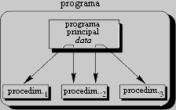

# Programación Orientada a Objetos (POO)

El principal impulso detrás de la invención de la Programación Orientada a Objetos (POO) ha sido la necesidad de abordar y superar las limitaciones presentes en el enfoque procedimental. A diferencia del método procedimental, donde los datos fluyen libremente, la POO pone a los datos en el centro de la escena, otorgándoles un papel crítico en el desarrollo de programas.

## Ventajas de la POO sobre el Enfoque Procedimental:

- Vinculación de Datos y Funciones: La POO no sólo limita el flujo libre de datos, sino que también los vincula estrechamente con las funciones que actúan sobre ellos. Esta estrecha relación asegura que los datos estén protegidos contra modificaciones no intencionadas por funciones ajenas.
- Descomposición en Objetos: La solución de problemas en POO se realiza dividiendo el problema en diversas entidades conocidas como objetos. A partir de ahí, se construyen datos y funciones específicas alrededor de estos objetos. Sin embargo, estas funciones tienen la capacidad de acceder a las funciones de otros objetos.

## Características Principales de la POO:

- Centrado en Datos: A diferencia del enfoque procedimental, en la POO el énfasis se coloca en los datos, no en el procedimiento.
- División en Objetos: Los programas se estructuran en entidades denominadas objetos.
- Estructuración de Datos: Se diseñan estructuras de datos que representan y caracterizan a los objetos.
- Encapsulamiento: Las funciones que actúan sobre los datos de un objeto están contenidas dentro de la estructura de datos del objeto, asegurando que los datos estén ocultos y protegidos de funciones externas.
- Comunicación entre Objetos: Aunque los datos están protegidos, los objetos pueden interactuar y comunicarse entre sí mediante funciones.
- Extensibilidad: Se facilita la adición de nuevos datos y funciones según las necesidades del programa.
- Diseño Inferior-Superior: A diferencia del enfoque procedimental, la POO adopta un enfoque de diseño que parte desde los detalles más específicos y se dirige hacia una visión más global.

## Definición de POO:

Dada la variedad de interpretaciones sobre la Programación Orientada a Objetos, es crucial establecer una definición clara. Consideramos la POO como un método que permite modularizar programas al crear áreas de memoria que albergan tanto datos como funciones. Estas áreas, denominadas objetos, actúan como plantillas, permitiendo crear copias de estos módulos según sea necesario. En esencia, un objeto es una sección delimitada de la memoria de la computadora que contiene datos y un conjunto de operaciones que pueden manipular esos datos. Dada su independencia, estos objetos pueden incorporarse en diversos programas sin requerir modificaciones.

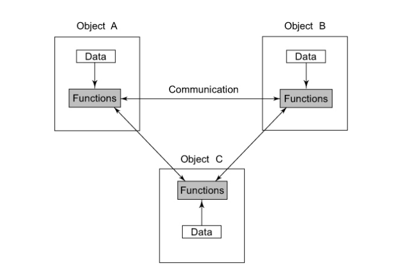

# Objetos

En un sistema orientado a objetos, los objetos son las entidades fundamentales durante la ejecución. Estos pueden representar una amplia variedad de elementos, desde personas, lugares y cuentas bancarias hasta tablas de datos. Además, pueden simbolizar datos definidos por el usuario, como vectores, unidades de tiempo y listas. Al abordar un problema de programación, se examina en función de los objetos y la comunicación entre ellos.

Es esencial que los objetos seleccionados en el programa reflejen con precisión los objetos del mundo real. Estos objetos ocupan un espacio en la memoria y poseen una dirección asociada, similar a un registro en Pascal o a una estructura en C. Durante la ejecución de un programa, los objetos interactúan enviándose mensajes mutuamente. Por ejemplo, en un programa donde "cliente" y "cuenta" sean dos objetos, el objeto "cliente" podría enviar un mensaje al objeto "cuenta" solicitando su saldo.

Cada objeto no solo alberga datos, sino también el código necesario para manipularlos. Lo interesante de esta interacción es que los objetos pueden comunicarse entre sí sin necesidad de conocer en detalle los datos o el código del otro. Basta con saber qué tipo de mensaje se puede enviar y qué tipo de respuesta se puede esperar.

# Clases

En un entorno de programación orientada a objetos, la clase sirve como un prototipo que encapsula el conjunto completo de datos y código que define a un objeto. Esencialmente, una clase permite modelar un tipo de datos definido por el usuario. Una vez definida una clase, es posible generar múltiples instancias o objetos que sean de ese tipo de clase. Estos objetos almacenan datos específicos según las definiciones de su clase asociada.

Así, una clase puede considerarse como un agrupamiento de objetos con características similares. Por ejemplo, si consideramos frutas como "mango", "manzana" y "naranja", todos estos pueden ser vistos como instancias de una clase denominada "fruta".

Las clases, en este contexto, funcionan como tipos de datos personalizados, pero para el programador, se comportan de manera similar a los tipos de datos primitivos o integrados que ofrece un lenguaje de programación. La forma en que se instancia un objeto de una clase es bastante directa y recuerda a cómo se declaran variables de tipos básicos. Por ejemplo, si hemos definido "fruta" como una clase, la línea de código fruta mango; crearía una instancia llamada "mango" que pertenece a la clase "fruta".